# Australia Weather Analysis from 2008 to 2017

Abilash Rao Vavilala

31/07/2021

[figure not shown]

This Report will provide you easy interpretation of Weather Analysis in Australia from 2008 to 2017. The source of this data is from Australian Government Bureau of Meteorology. The observation of weather in Australia is monitored by Australian Government Bureau of Meteorology. We have Data for 49 cities and regions across Australia. however, we will mainly focus on weather in Two Major cities Sydney and Melbourne. Hottest Day recorded durig this period is 48.1. this was in woomera on 2011 - 01- 25.

```r
library(lubridate)
library(tidyverse)
library(readxl)
library(readr)
urlfile <- "https://raw.githubusercontent.com/AbiVavilala/Australian-Weather-Report/main/weatherAUS.csv"

weather <- read.csv(url(urlfile))
weather$Date <- as.Date(weather$Date)
weather$year <- year(weather$Date)
weather$month <- months(weather$Date)
weather$month <- factor(weather$month, levels = month.name)

max(weather$MaxTemp, na.rm = T)
```

```
## [1] 48.1
```

```r
unique(weather$Location)
```

```
##  [1] "Albury"           "BadgerysCreek"    "Cobar"            "CoffsHarbour"
##  [5] "Moree"            "Newcastle"        "NorahHead"        "NorfolkIsland"
##  [9] "Penrith"          "Richmond"         "Sydney"           "SydneyAirport"
## [13] "WaggaWagga"       "Williamtown"      "Wollongong"       "Canberra"
## [17] "Tuggeranong"      "MountGinini"      "Ballarat"         "Bendigo"
## [21] "Sale"             "MelbourneAirport" "Melbourne"        "Mildura"
## [25] "Nhil"             "Portland"         "Watsonia"         "Dartmoor"
## [29] "Brisbane"         "Cairns"           "GoldCoast"        "Townsville"
## [33] "Adelaide"         "MountGambier"     "Nuriootpa"        "Woomera"
## [37] "Albany"           "Witchcliffe"      "PearceRAAF"       "PerthAirport"
## [41] "Perth"            "SalmonGums"       "Walpole"          "Hobart"
## [45] "Launceston"       "AliceSprings"     "Darwin"           "Katherine"
## [49] "Uluru"
```

# Temperature analysis for Sydney fromm 2008 to 2017:

We will look at the minimum and maximum temperature recorded in Sydney for this time period. I will provided Graphical representation so we can clearly see there is a clear increase in Temperature

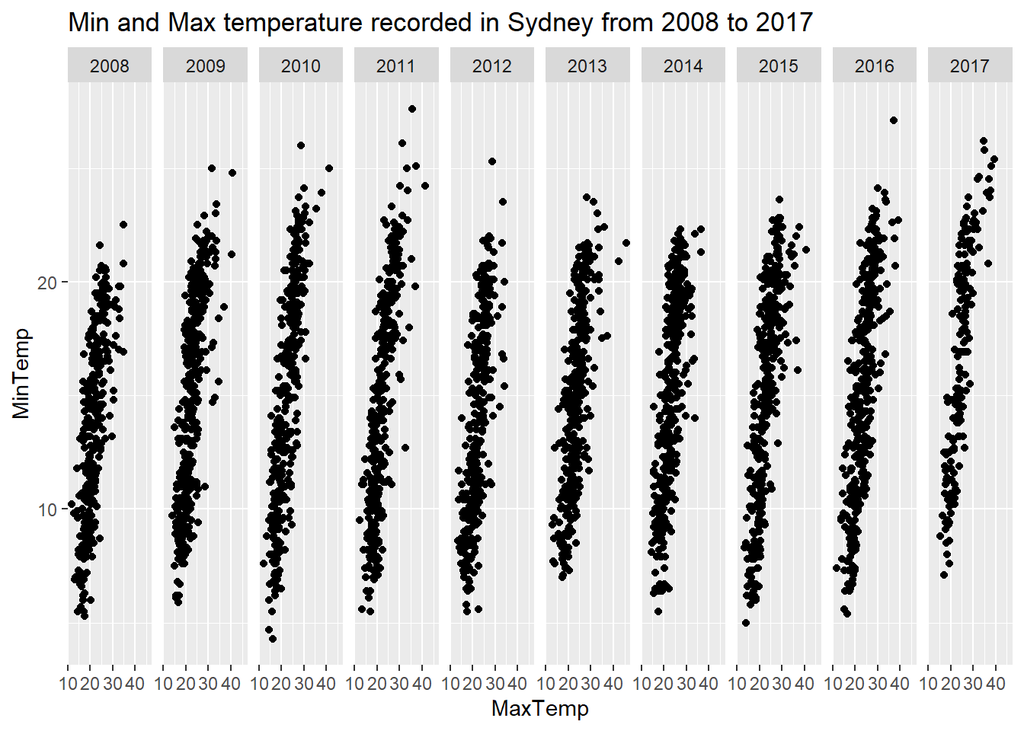

```r
sydney_weather <- weather %>% filter(Location == "Sydney")
sydney_weather$temp_interval <- cut(sydney_weather$MaxTemp, breaks = seq(0,50, by = 3))


sydney_weather %>% ggplot(aes(MaxTemp, MinTemp)) + geom_point() + ggtitle("Min and Max temperature recorded in Sydney from 2008 to 2017") + facet_grid(.~year)
```

```r
syd_2008 <- sydney_weather %>% filter(sydney_weather$year == "2008")

syd_2009 <- sydney_weather %>% filter(sydney_weather$year == "2009")

syd_2010 <- sydney_weather %>% filter(sydney_weather$year == "2010")

syd_2011 <- sydney_weather %>% filter(sydney_weather$year == "2011")


syd_2012 <- sydney_weather %>% filter(sydney_weather$year == "2012")

syd_2013 <- sydney_weather %>% filter(sydney_weather$year == "2013")

syd_2014 <- sydney_weather %>% filter(sydney_weather$year == "2014")

syd_2015 <- sydney_weather %>% filter(sydney_weather$year == "2015")

syd_2016 <- sydney_weather %>% filter(sydney_weather$year == "2016")


syd_2017 <- sydney_weather %>% filter(sydney_weather$year == "2017")
```

```r
mean(syd_2008$MaxTemp, na.rm = T)
```

```
## [1] 21.72776
```

```r
mean(syd_2009$MaxTemp, na.rm = T)
```

```
## [1] 22.89284
```

```r
mean(syd_2010$MaxTemp, na.rm = T)
```

```
## [1] 22.57205
```

```r
mean(syd_2011$MaxTemp, na.rm = T)
```

```
## [1] 22.56
```

```r
mean(syd_2012$MaxTemp, na.rm = T)
```

```
## [1] 22.36209
```

```r
mean(syd_2013$MaxTemp, na.rm = T)
```

```
## [1] 23.50267
```

```r
mean(syd_2014$MaxTemp, na.rm = T)
```

```
## [1] 23.44438
```

```r
mean(syd_2015$MaxTemp, na.rm = T)
```

```
## [1] 23.14685
```

```r
mean(syd_2016$MaxTemp, na.rm = T)
```

```
## [1] 23.84016
```

```r
mean(syd_2017$MaxTemp, na.rm = T)
```

```
## [1] 24.68352
```

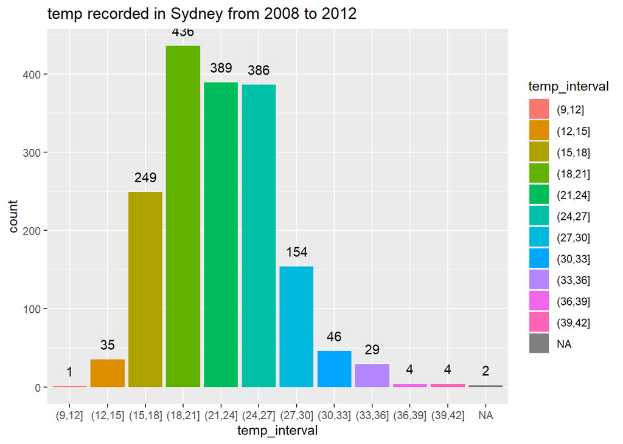

```r
sydney_weather_2008_2012 <- sydney_weather %>% filter(year %in% c("2008", "2009", "2010", "2011", "2012"))

sydney_weather_2013_2017 <- sydney_weather %>% filter(year %in% c("2013", "2014", "2015", "2016", "2017"))

sydney_weather_2008_2012 %>% ggplot(aes(temp_interval, fill = temp_interval)) + geom_bar() + ggtitle("temp recorded in Sydney from 2008 to 2012") + geom_text(stat='count', aes(label=..count..), vjust=-1)
```

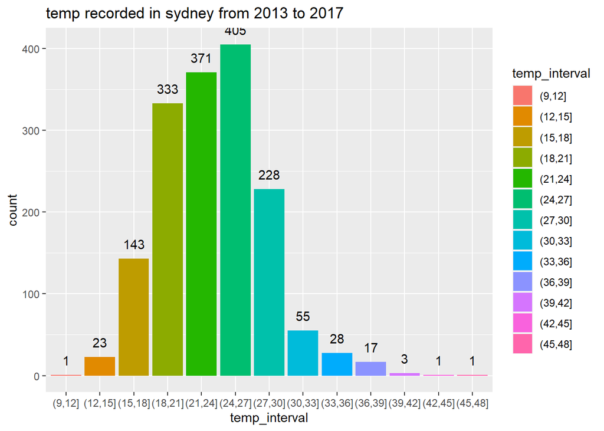

```r
sydney_weather_2013_2017 %>% ggplot(aes(temp_interval, fill = temp_interval)) + geom_bar() + ggtitle("temp recorded in sydney from 2013 to 2017") + geom_text(stat='count', aes(label=..count..), vjust=-1)
```